# Creating presentations with R Markdown

## Brief overview of ioslides | Creating slides with R Markdown

- To create an **ioslides** presentation from R Markdown, specify *ioslides_presentation* in the YAML header
  - **beamer** and **slidy** are other presentation types

```r
---
title: "Formatted Output & R Markdown Presentations"
output:
  ioslides_presentation: default
---
```

## Brief overview of ioslides | Creating slides with R Markdown

- Use # for a new section, ## for a new slide, and | for adding a subtitle
- Can set slides to display smaller text {.smaller} or display the slide content incrementally {.build} as in this slide.

```r
## Slide title {.smaller .build}
```

[Here](https://garrettgman.github.io/rmarkdown/ioslides_presentation_format.html) is a short tutorial. See Chapter 4.1 in [R Markdown: The Definitive Guide](https://bookdown.org/yihui/rmarkdown/ioslides-presentation.html) for a more comprehensive treatment.

# Including output in your slides

## Loading packages

This presentation uses some familiar packages to generate and display results:

- `tidyverse`
- `fixest`
- `lmtest`
- `multiwayvcov`
- `kableExtra`

Plus some packages for creating tables with formatted output:

- `stargazer`
- `modelsummary`

## Loading data objects for this presentation

Load in the data objects you need, saved after creating in your R script.

Can load an **.rdata** file with many objects:

```r
load("formatted_output_slides.RData") #includes objects from diff lessons
```

Or you can load an **.rds** file for a single object:

```r
feDF <- readRDS(file = "feDF.rds") #a single data frame from the Medicaid lesson
```

## Difference-in-means tables

Suppose we’re interested in comparing the *poverty rate* and *vfund_per_poor* of regencies between Java and Sulawesi islands.

[Here](https://sebastiansauer.github.io/multiple-t-tests-with-dplyr/) is a tutorial for making this kind of table using `tidyverse` functions.

| Variable | Java | Sulawesi | Difference | p-value |
| --- | --- | --- | --- | --- |
| Population in poverty (1000s) | 137.60 | 26.25 | 111.35 | 0.000 |
| VF allocation/poor resident ($1000s) | 1773.33 | 4603.95 | -2830.62 | 0.000 |

## Difference-in-means tables

Here is another example using the `datasummary_balance()` [function](https://modelsummary.com/man/datasummary_balance.html) in the `modelsummary` [package](https://vincentarelbundock.github.io/modelsummary/index.html).

Difference-in-means during year of Medicaid implementation by state eligilibity

|  | High-Eligibility (N=24) Mean | High-Eligibility (N=24) Std. Dev. | Low-Eligibility (N=25) Mean | Low-Eligibility (N=25) Std. Dev. | Diff. in Means | p |
| --- | --- | --- | --- | --- | --- | --- |
| afdc_rate | 3.01 | 0.73 | 1.56 | 0.33 | -1.45 | <0.01 |
| income_pc | 3.39 | 0.68 | 3.21 | 0.32 | -0.18 | 0.33 |
| hospitals_pc | 0.03 | 0.01 | 0.03 | 0.02 | 0.00 | 0.40 |
| beds_pc | 4.90 | 0.74 | 5.09 | 0.71 | 0.19 | 0.44 |

Note: States are weighted by child population.

**Upside to this function:**

- Can show formatted output without much work

**Downside:**

- Isn’t very flexible compared to previous approach

## Using Stargazer for formatted output

`stargazer` is an R package that creates LATEX code, HTML code and ASCII text for well-formatted regression tables, with multiple models side-by-side, as well as for summary statistics tables, data frames, vectors and matrices.”

[Here](https://www.jakeruss.com/cheatsheets/stargazer) is a good tutorial with numerous stargazer examples and formatting options.

## Regression results

Make we sure we know your PRF before reporting regression results!

We should also know how you estimate SEs, weight observations, and any other critical details.

For our Medicaid example, here is the PRF for our base difference-in-difference model with state and year fixed effects,

$$Y_{st} = \beta D_{st} + X_{st}'
\gamma + \mu_s + \tau_t + \varepsilon_{st}$$

where $Y_{st}$ is the outcome of interest in state $s$ and year $t$; $D_{st}$ is a binary variable indicating treatment status for a state-year; $X_{st}$ is a vector of time-varying controls (income, hospitals, and hospital beds per capita); $\mu_s$ represents state fixed effects; $\tau_{t}$ represents year fixed effects; and $\varepsilon_{st}$ is an idiosyncratic error term.

## Regression tables

Regression tables using `modelsummary()` with minimal customization:

|  | FE 1 | FE 2 | FE 3 | FE 4 | FE 5 |
| --- | --- | --- | --- | --- | --- |
| D | 0.101*** | 0.051** | 0.038*** | 0.038** | 0.045*** |
|  | (0.018) | (0.021) | (0.013) | (0.015) | (0.014) |
| hospitals_pc |  | 0.513 | 2.017 | 2.605** | 1.208 |
|  |  | (1.107) | (1.397) | (1.072) | (1.443) |
| beds_pc |  | −0.011 | −0.013 | −0.009 | −0.007 |
|  |  | (0.011) | (0.009) | (0.010) | (0.010) |
| income_pc |  | 0.025*** | 0.024 | 0.040* | 0.036* |
|  |  | (0.004) | (0.020) | (0.020) | (0.021) |
| Num.Obs. | 685 | 685 | 685 | 685 | 685 |
| R2 | 0.662 | 0.824 | 0.906 | 0.888 | 0.923 |
| R2 Adj. | 0.636 | 0.810 | 0.886 | 0.860 | 0.890 |
| R2 Within | 0.421 | 0.699 | 0.197 | 0.197 | 0.222 |
| R2 Within Adj. | 0.420 | 0.697 | 0.191 | 0.191 | 0.215 |
| RMSE | 0.04 | 0.03 | 0.03 | 0.02 | 0.02 |
| Std.Errors | by: stfips | by: stfips | by: stfips | by: stfips | by: stfips |
| FE: stfips | X | X | X | X | X |
| FE: region^year |  |  | X |  | X |
| FE: year_mcaid^year |  |  |  | X | X |

* p < 0.1, ** p < 0.05, *** p < 0.01

## Regression tables

Regression tables using `modelsummary()` with additional customization:

Effect of high Medicaid eligibility on public insurance use

|  | FE 1 | FE 2 | FE 3 | FE 4 | FE 5 |
| --- | --- | --- | --- | --- | --- |
| High-eligibility | 0.101*** | 0.051** | 0.038*** | 0.038** | 0.045*** |
|  | (0.018) | (0.021) | (0.013) | (0.015) | (0.014) |
| Hospitals per capita |  | 0.513 | 2.017 | 2.605** | 1.208 |
|  |  | (1.107) | (1.397) | (1.072) | (1.443) |
| Hospital beds per capita |  | −0.011 | −0.013 | −0.009 | −0.007 |
|  |  | (0.011) | (0.009) | (0.010) | (0.010) |
| Income per capita |  | 0.025*** | 0.024 | 0.040* | 0.036* |
|  |  | (0.004) | (0.020) | (0.020) | (0.021) |
| N | 685 | 685 | 685 | 685 | 685 |
| State FEs | X | X | X | X | X |
| Region-Year FEs |  |  | X |  | X |
| Medicaid timing-by-Year FEs |  |  |  | X | X |

* p < 0.1, ** p < 0.05, *** p < 0.01  
Robust standard errors clustered by state are shown in parentheses. Observations are weighted by the child population in each state.

See this [resource](https://vincentarelbundock.github.io/modelsummary/articles/modelsummary.html) for more details on `modelsummary().`

## Regression tables

Here is another example from the Detroit water shutoff analysis that relies on `lm()` for FE estimation and `stargazer` for formatting results. The full PRF is:

$$total\_obs\_1000_{zt} = \beta_0 +
\beta_1 si\_1000_{zt} + \beta_2 vac\_res\_p100_{zt} + \phi_z + \theta_t
+ u_{zt}$$

Columns 1 and 2 show results without controlling for vacancy rates, columns 3 and 4 include vacancy rate as a control variable.

|  | *Dependent variable:* |  |  |  |
| --- | --- | --- | --- | --- |
|  | total_obs_1000 |  |  |  |
|  | (1) | (2) | (3) | (4) |
| si_1000 | 0.013** | 0.013* | 0.016*** | 0.016** |
|  | (0.006) | (0.007) | (0.006) | (0.007) |
| vac_res_p100 |  |  | -0.156*** | -0.156*** |
|  |  |  | (0.012) | (0.059) |
| Constant | 17.562*** | 17.562*** | 18.351*** | 18.351*** |
|  | (0.302) | (0.251) | (0.274) | (0.307) |
| Zip code FE | Yes | Yes | Yes | Yes |
| Month FE | Yes | Yes | Yes | Yes |
| Clustered SEs | No | Zipcode | No | Zipcode |
| Mean dep var | 12.43 | 12.43 | 12.43 | 12.43 |
| Observations | 2,880 | 2,880 | 2,784 | 2,784 |
| Adjusted R<sup>2</sup> | 0.835 | 0.835 | 0.846 | 0.846 |
| *Note:* | p<0.1; p<0.05; p<0.01 |  |  |  |
|  | Robust standard errors are shown in parentheses unless otherwise indicated. |  |  |  |

# Additional ioslides formatting

## Creating bullet points lists

- This is a bullet point
- This is another bullet point
  - With a sub bullet

## Add a plot

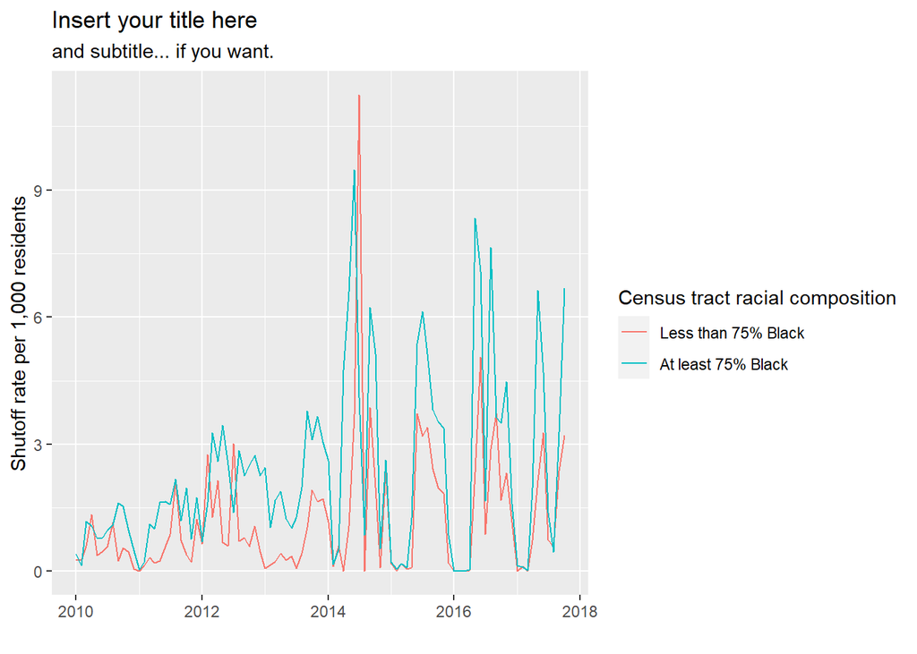

Make sure to clearly label your axes and legend!

Note that when you’re working with panel data, descriptive time series plots  
by group can help motivate your analysis.

## Tips for your presentation

- Remember to do all of your work in R script(s) and only load the objects you need into your .rmd file (use .RData and .rds files)
- Don’t describe your code and nonessential data management details, describe your analysis and results.
- Having extra appendix slides on hand is fine, but don’t try to cover too much! Stick to the essential parts of your story.
- Don’t forget to spellcheck and review your knitted document!